# Análisis exploratorio: Default de pago de tarjetas de crédito

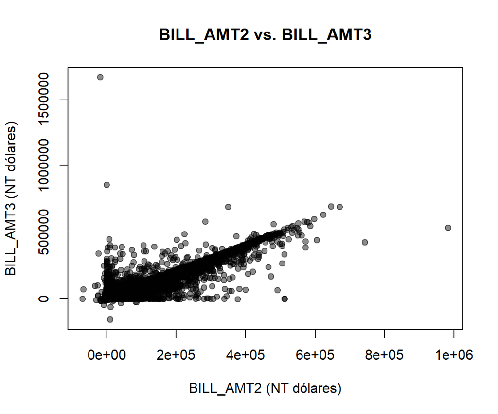

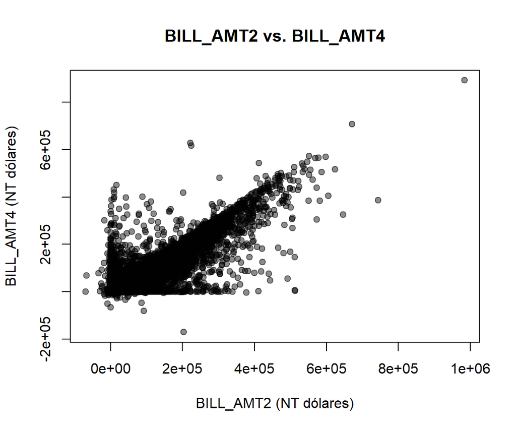

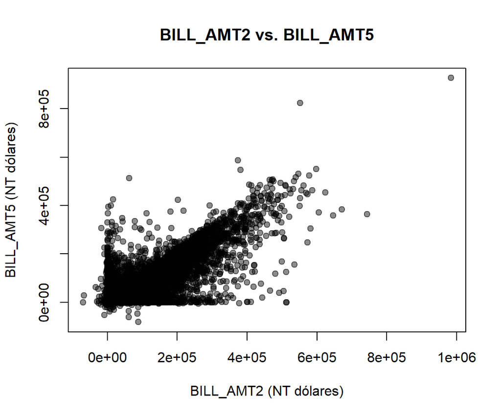

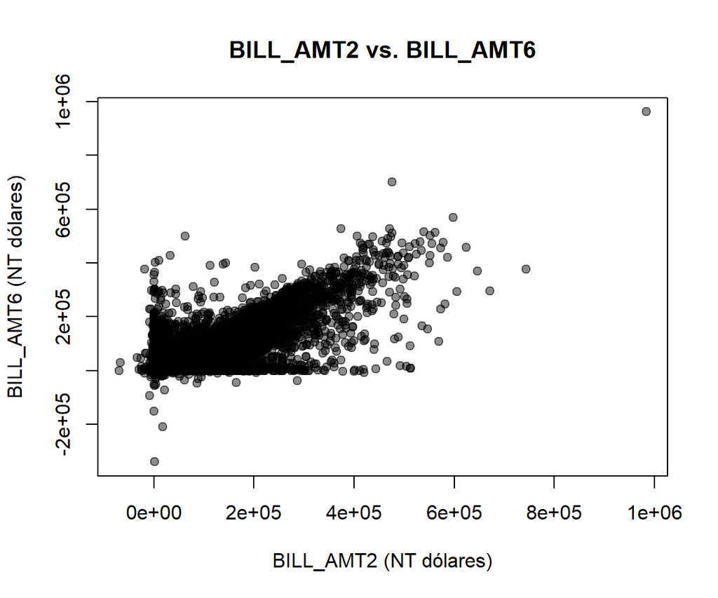

**Interpretación:**

Este conjunto de gráficos representa la relación entre los estados de cuenta correspondientes a **septiembre (`BILL_AMT1`) y agosto (`BILL_AMT2`)** y los estados de cuenta registrados en los demás períodos.

Los gráficos presentan un **comportamiento creciente**, evidenciando una asociación positiva entre los montos registrados en diferentes períodos.

La mayor variación se concentra en los valores cercanos a cero, mientras que los valores más elevados presentan una distribución progresivamente creciente.

En conjunto, se observa una relación consistente entre los montos de los estados de cuenta de los diferentes períodos, aunque existen diferencias en la magnitud de los valores registrados en cada mes.

## GRUPO 6: BILL_AMT3, BILL_AMT4 y BILL_AMT5 vs. BILL_AMT

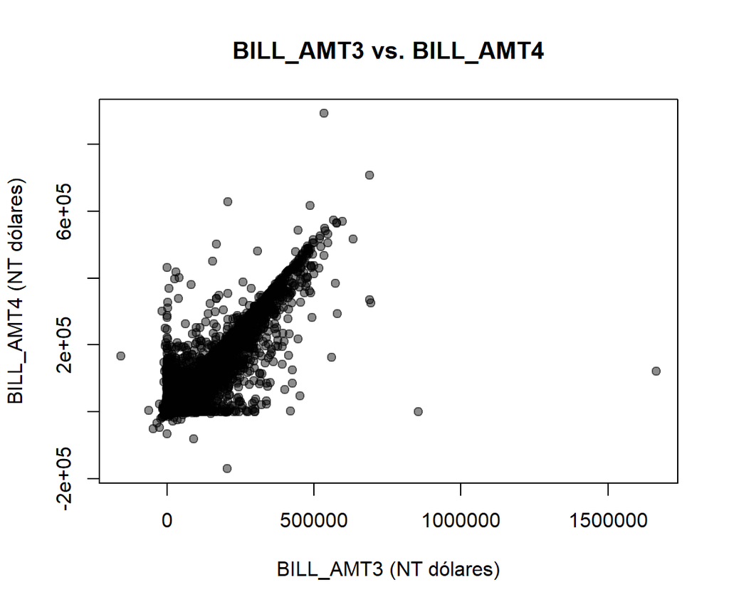

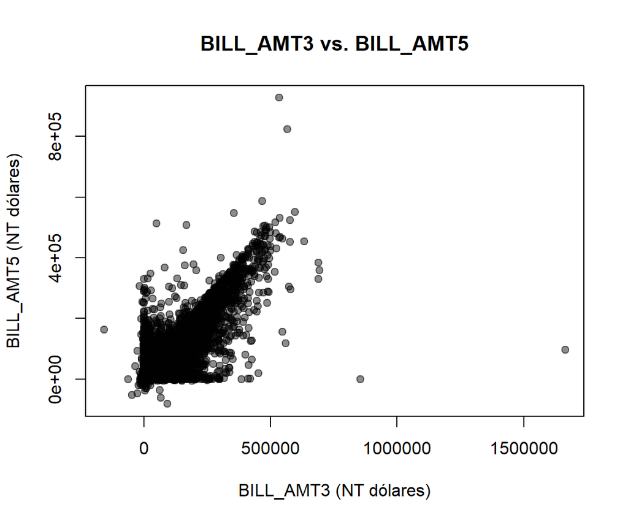

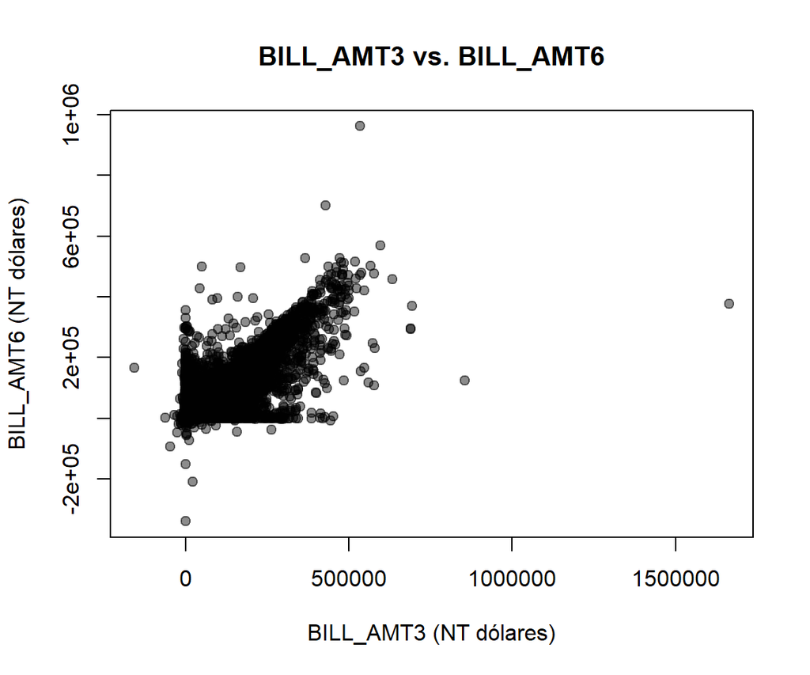

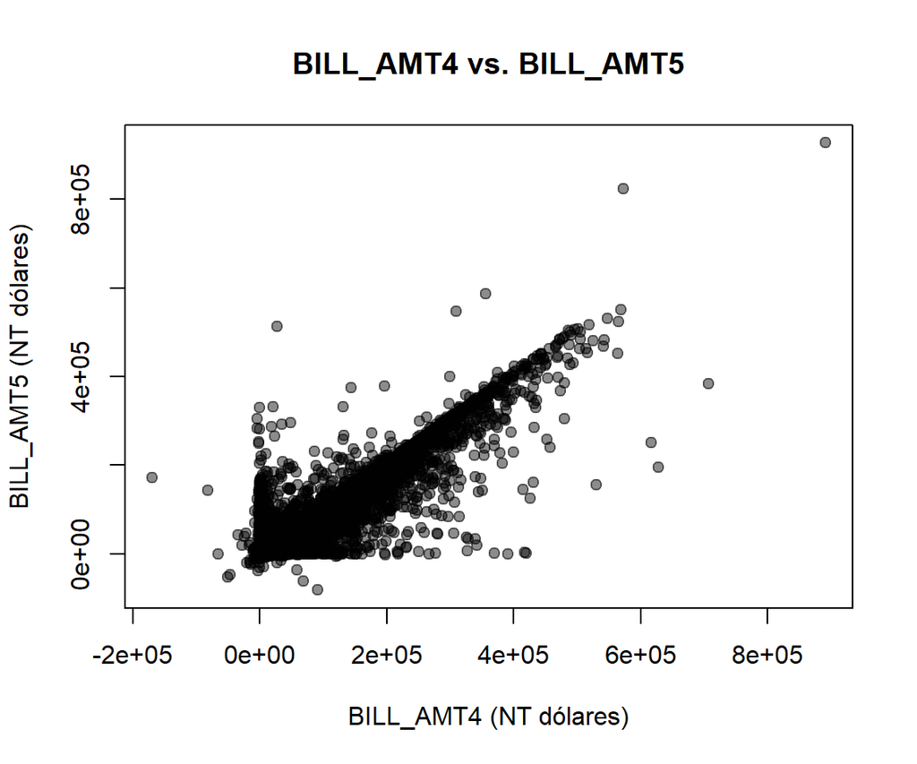

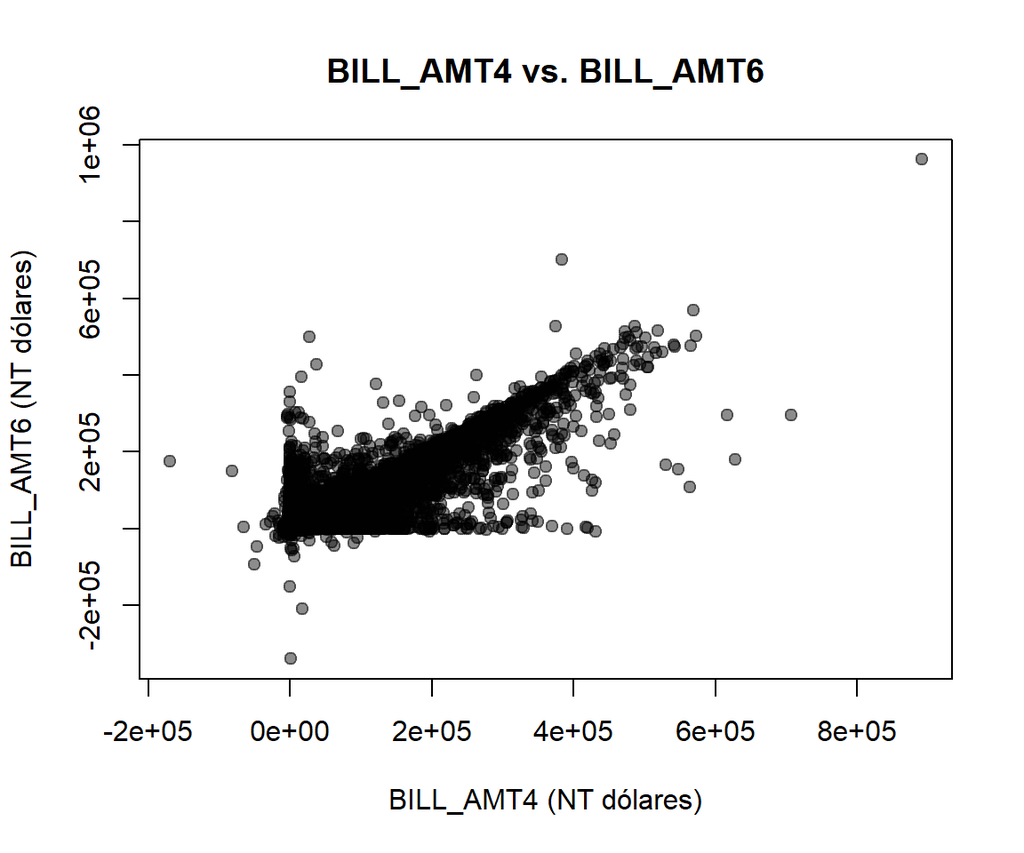

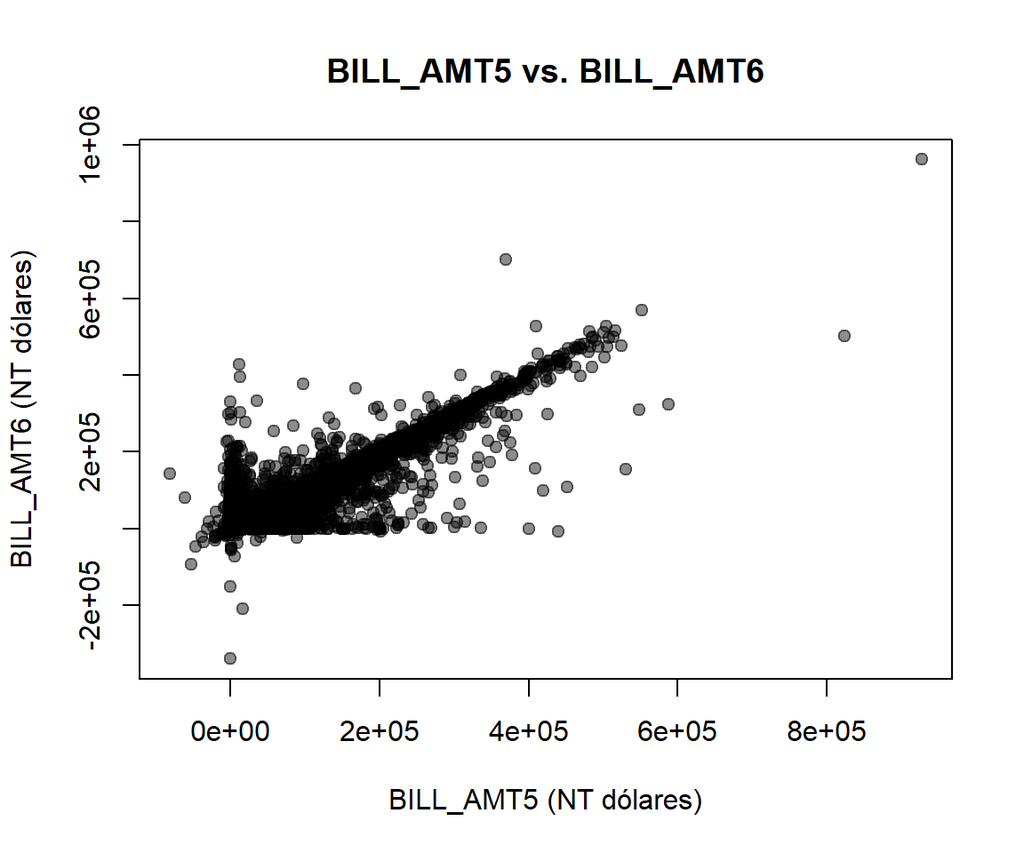

**Interpretación:**

Este conjunto de gráficos representa la relación entre los estados de cuenta correspondientes a otros períodos del conjunto de datos, específicamente `BILL_AMT3`, `BILL_AMT4` y `BILL_AMT5`, y los valores registrados en los demás meses.

Al igual que en el Grupo 5, se observa un **comportamiento creciente** entre los diferentes montos de los estados de cuenta.

Sin embargo, en este grupo algunas relaciones presentan una pendiente más pronunciada y una distribución más cercana a una correspondencia proporcional entre los períodos comparados.

También se observa una mayor concentración de los puntos alrededor de la tendencia creciente, especialmente al comparar períodos cercanos entre sí.

Las comparaciones entre meses consecutivos muestran diferencias en la magnitud de los montos, aunque mantienen una tendencia general similar.

En términos generales, los diferentes `BILL_AMT` presentan un comportamiento temporal consistente, caracterizado por asociaciones positivas entre los montos registrados en los distintos períodos.

## GRUPO 7: BILL_AMT vs. PAY_AMT

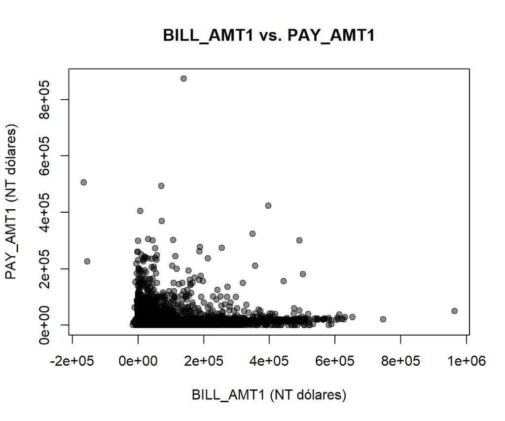

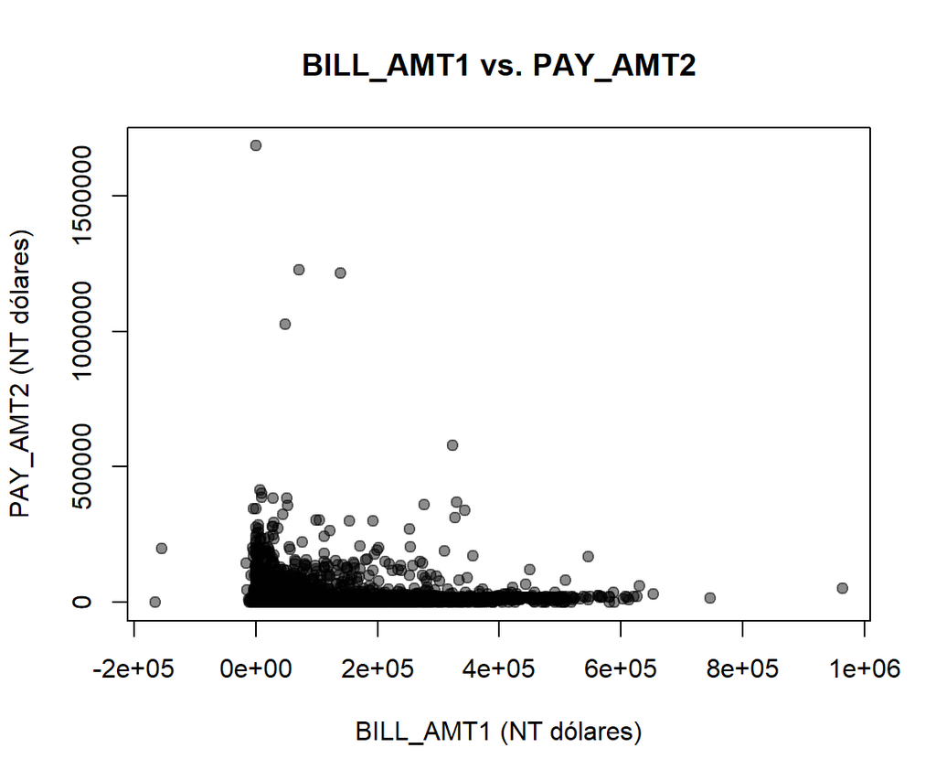

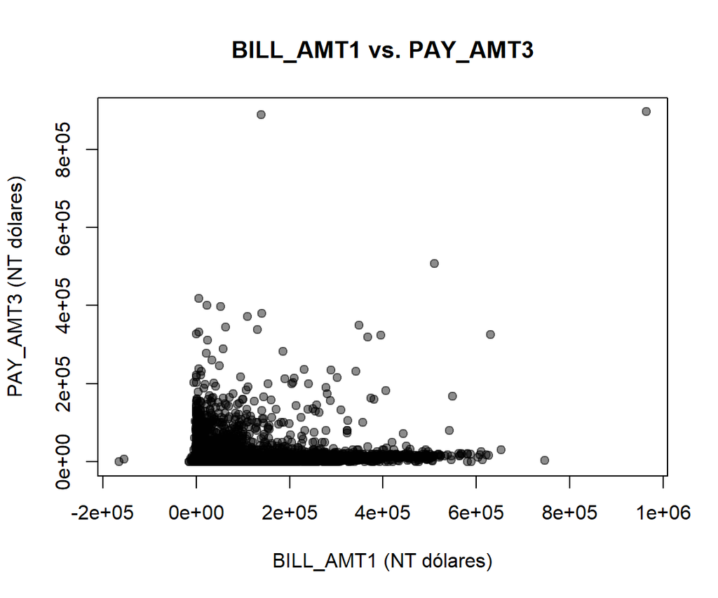

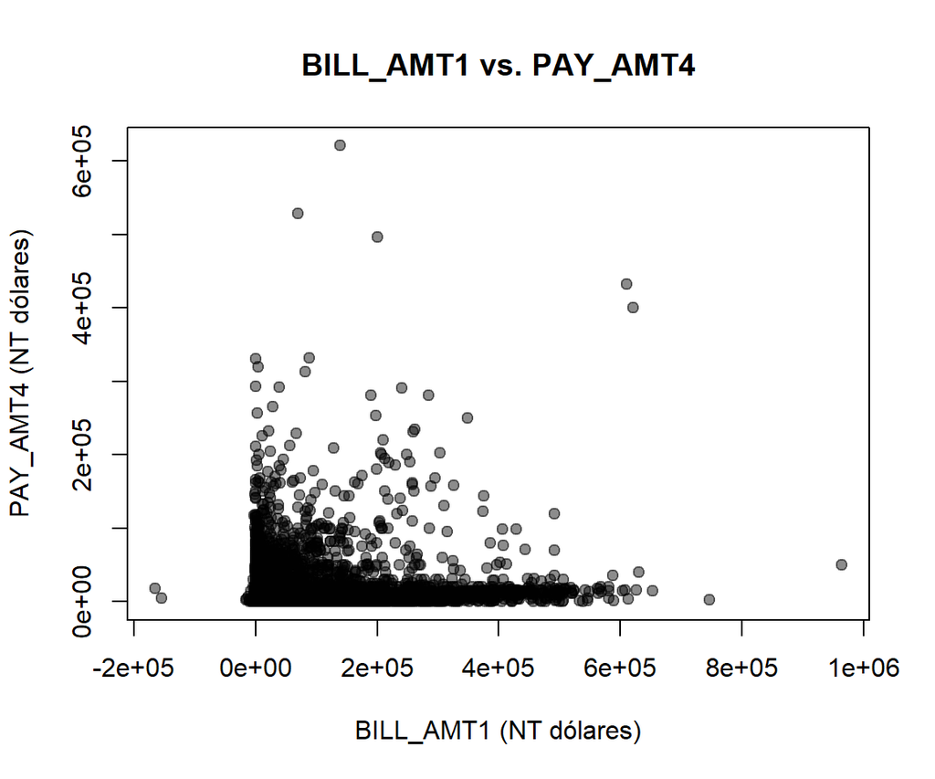

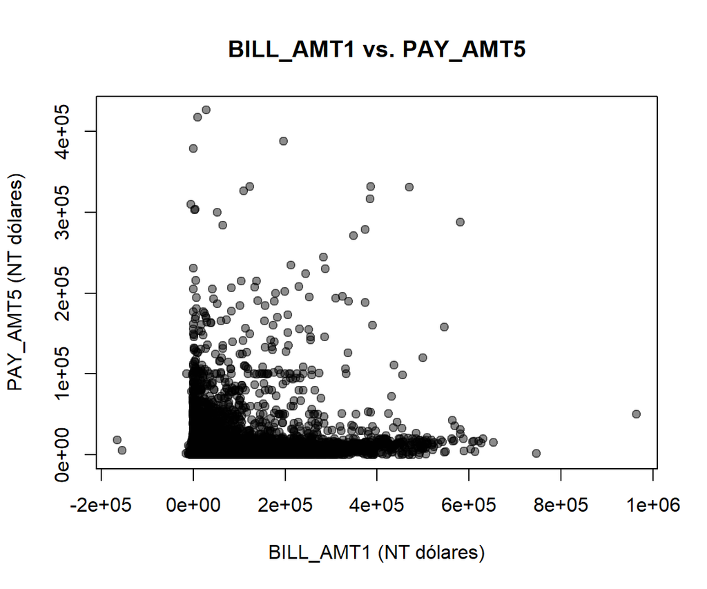

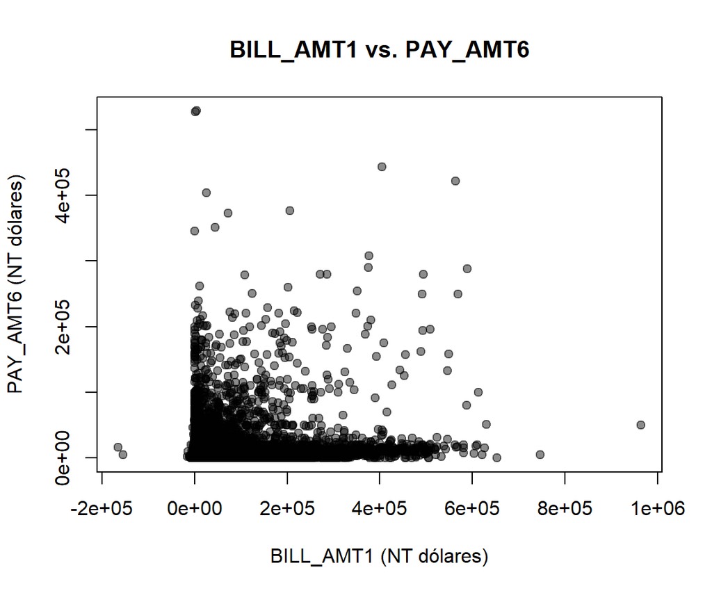

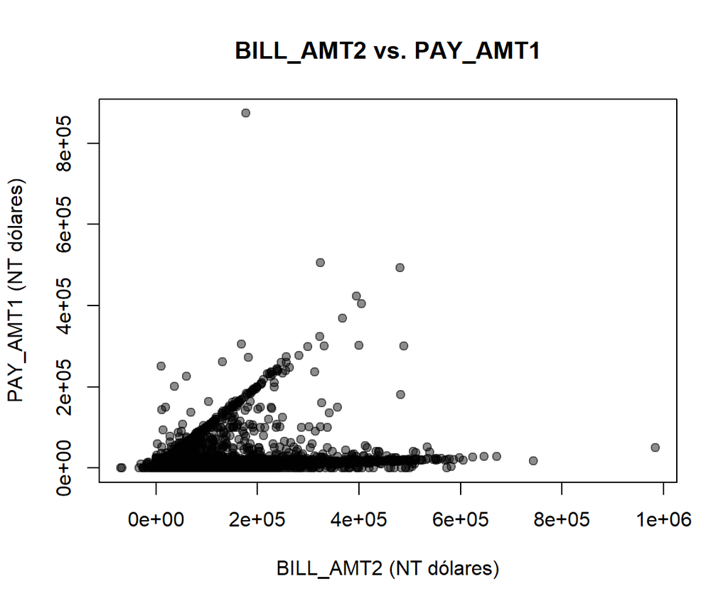

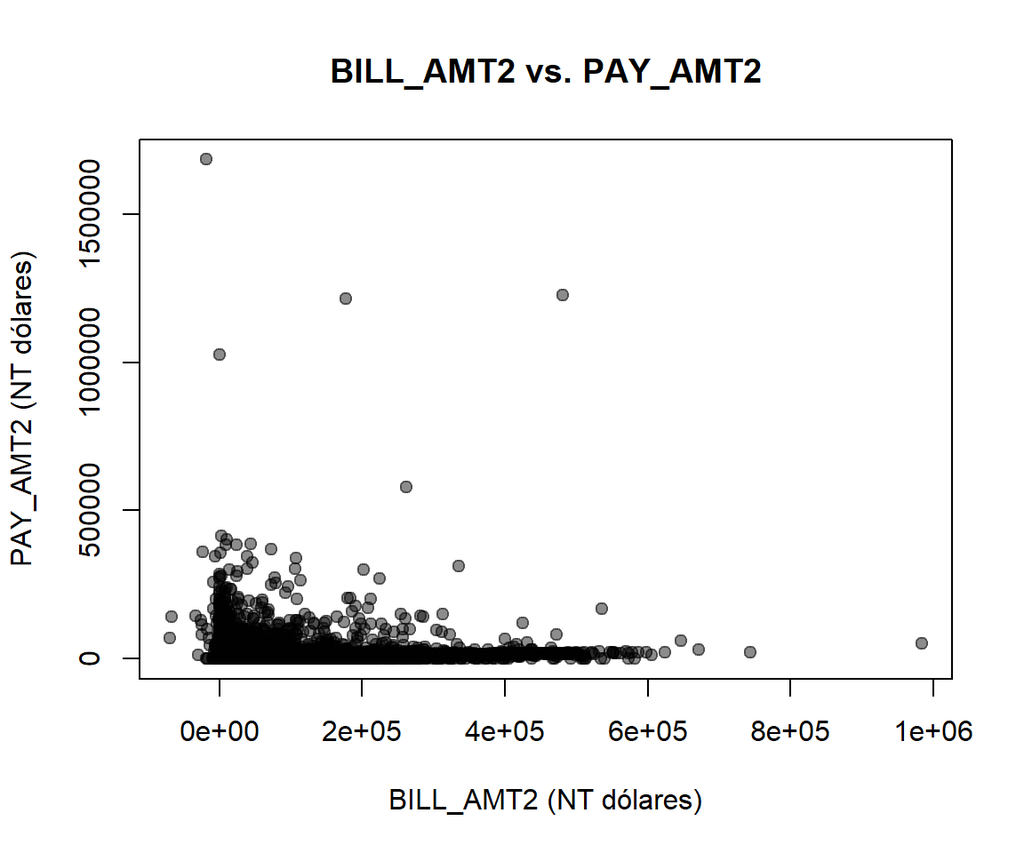

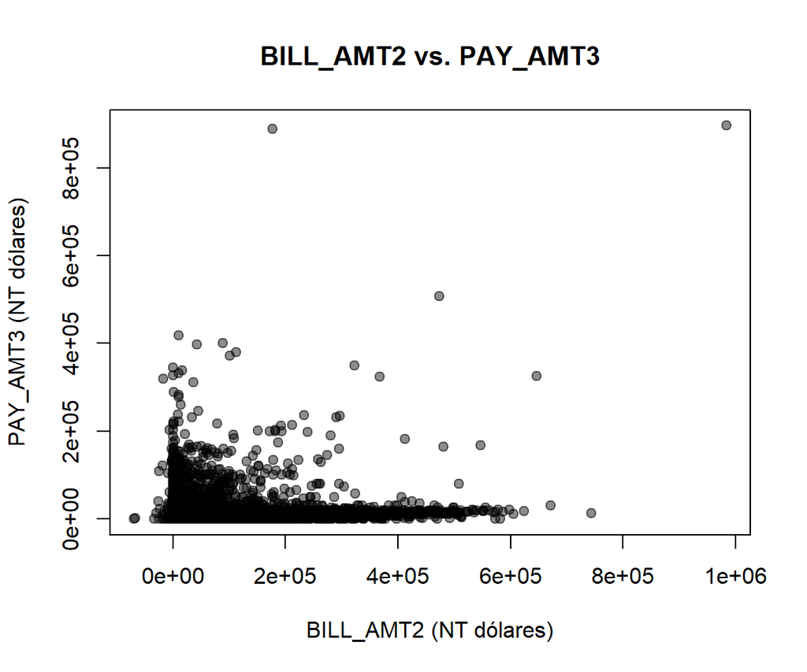

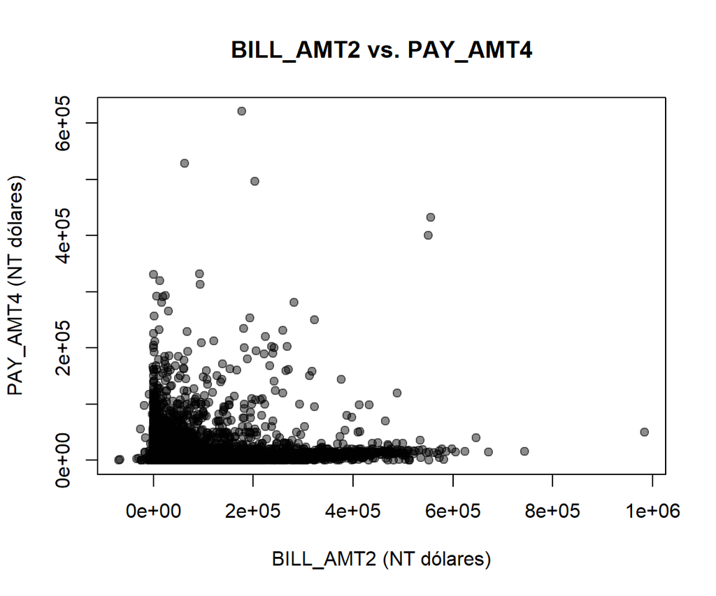

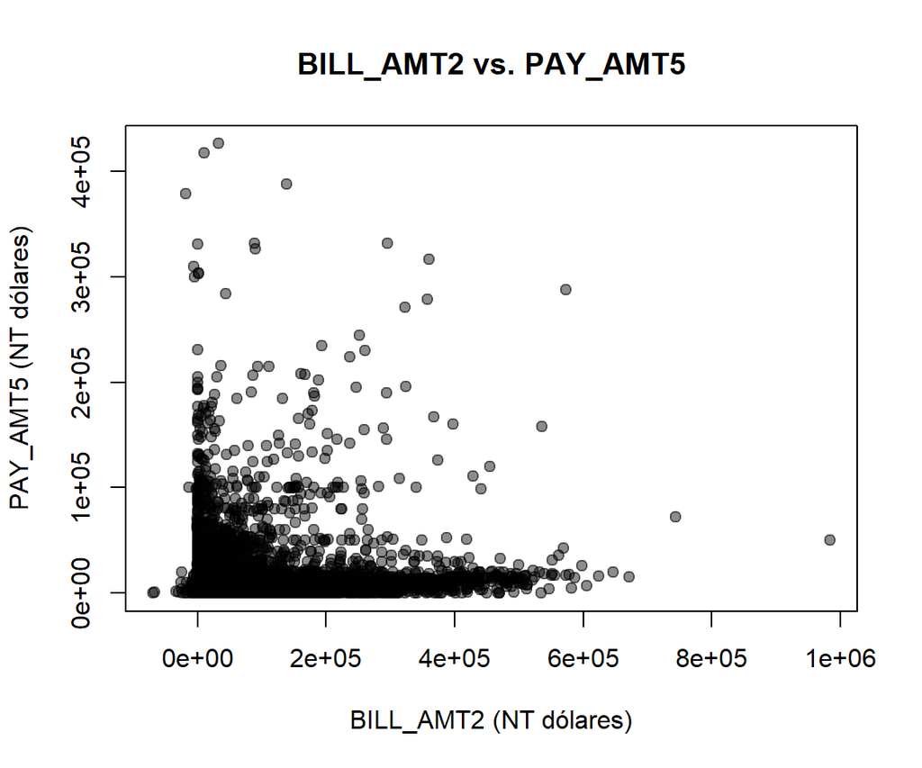

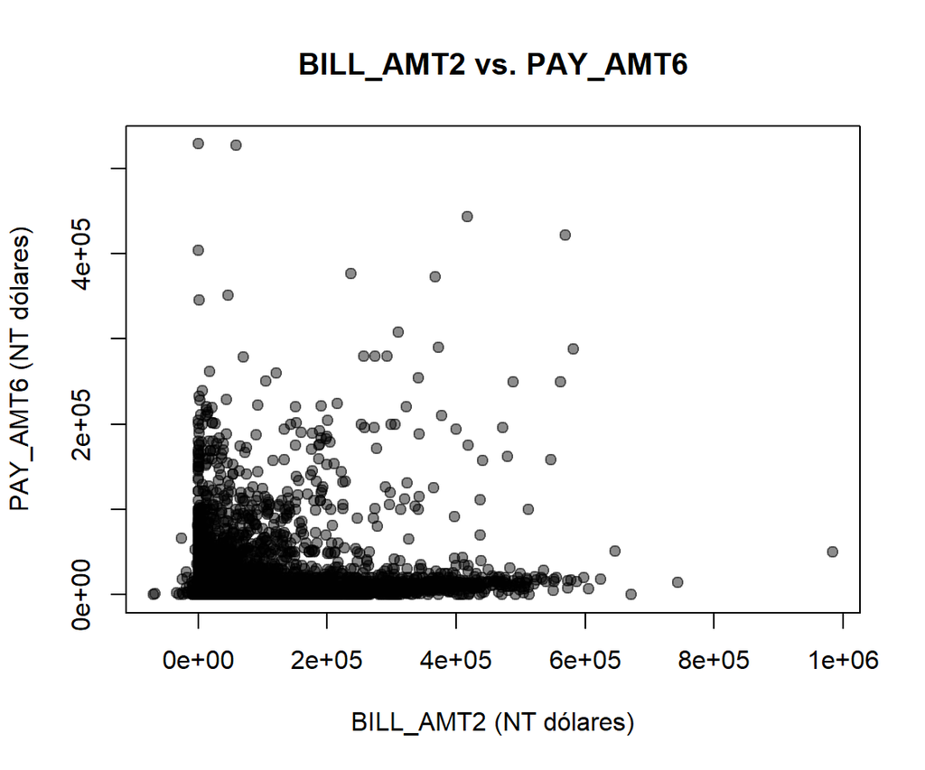

[24 more figures not shown]

**Interpretación:**

Este conjunto de gráficos representa la relación entre los **montos de los estados de cuenta (`BILL_AMT`)** y los **montos de los pagos realizados (`PAY_AMT`)** en los diferentes períodos.

En general, los gráficos presentan una **alta dispersión** de los valores de `PAY_AMT` respecto a `BILL_AMT`. No se observa una correspondencia uniforme entre ambas variables, especialmente en los valores elevados de los estados de cuenta.

En varias de las comparaciones, los pagos permanecen concentrados en valores relativamente bajos incluso cuando los montos de los estados de cuenta presentan valores considerablemente superiores.

Se identifican algunas combinaciones, como `BILL_AMT2` vs. `PAY_AMT1`, `BILL_AMT3` vs. `PAY_AMT1`, `BILL_AMT4` vs. `PAY_AMT3`, `BILL_AMT5` vs. `PAY_AMT4`, `BILL_AMT5` vs. `PAY_AMT6` y `BILL_AMT3` vs. `PAY_AMT2`, en las que se aprecia una mayor proximidad entre los valores de ambas variables.

Sin embargo, estas relaciones se presentan entre períodos diferentes, por lo que se observa una variación en la correspondencia entre el monto registrado en el estado de cuenta y el pago realizado.

En general, los gráficos muestran una **mayor dispersión entre `BILL_AMT` y `PAY_AMT`** en comparación con la relación observada entre los diferentes períodos de `BILL_AMT`.

## GRUPO 8: PAY_AMT vs. PAY_AMT

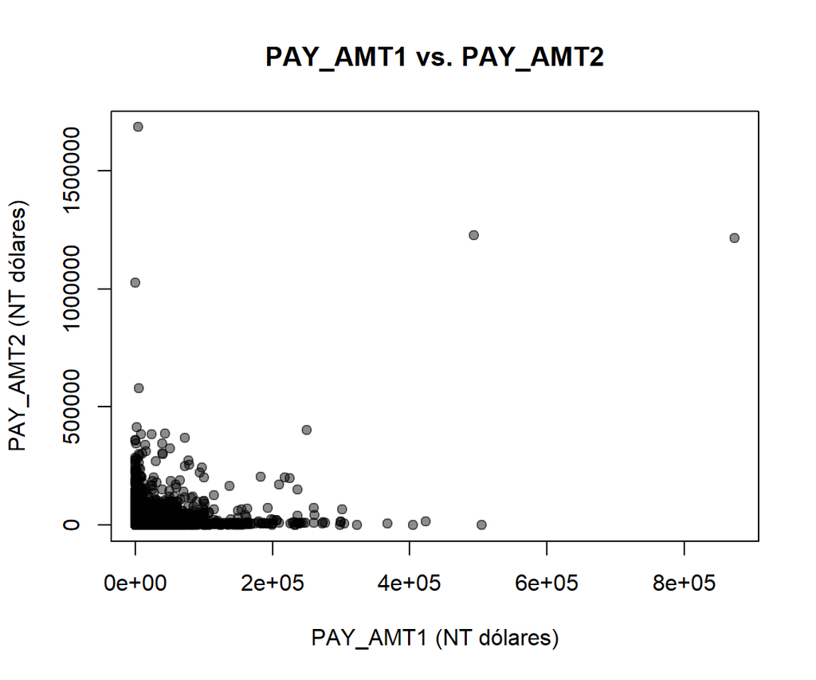

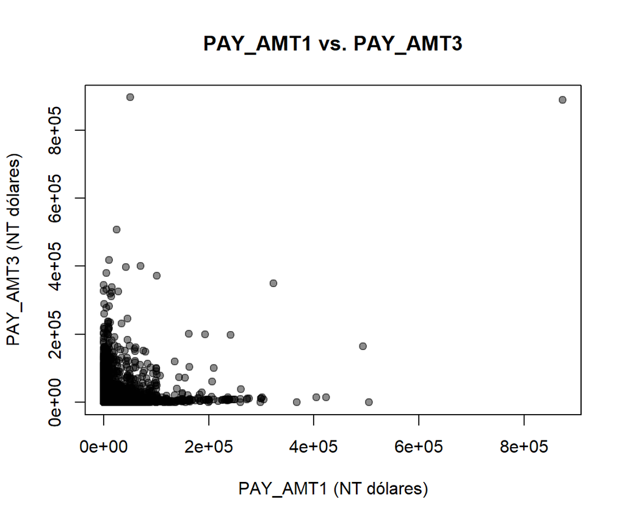

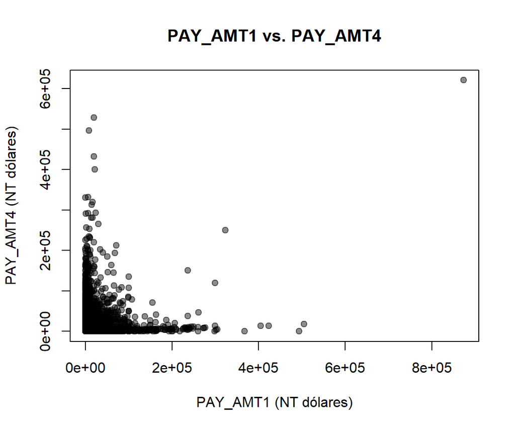

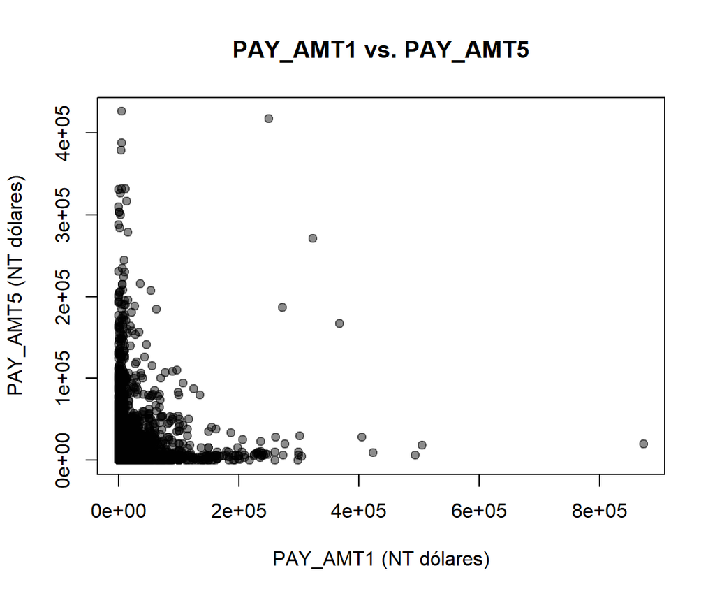

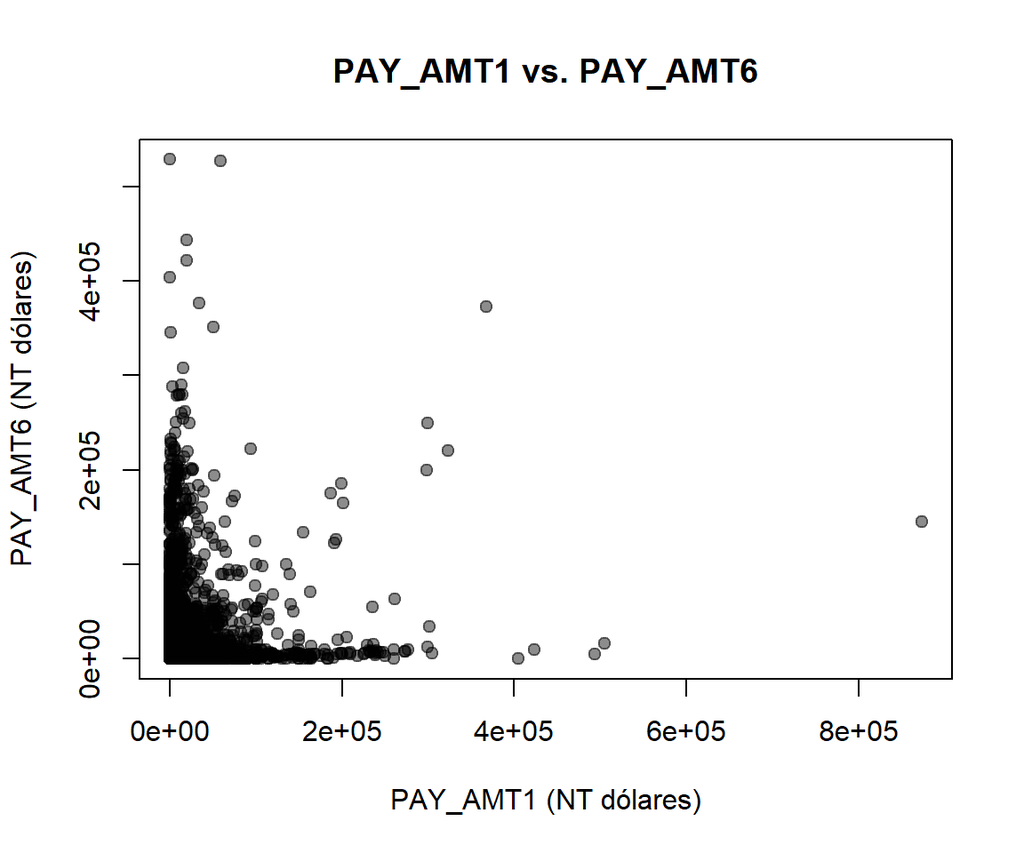

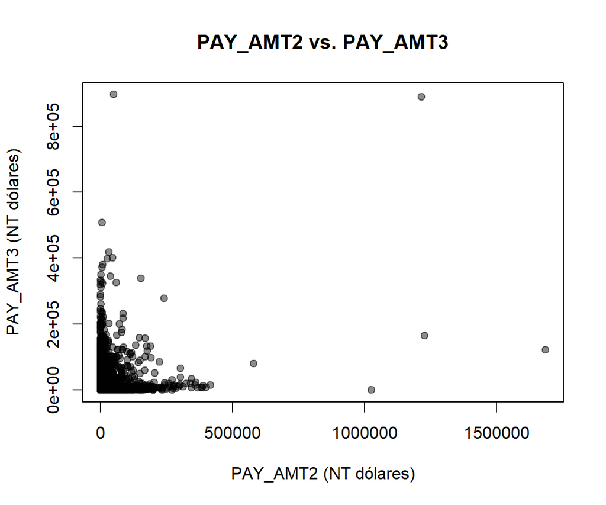

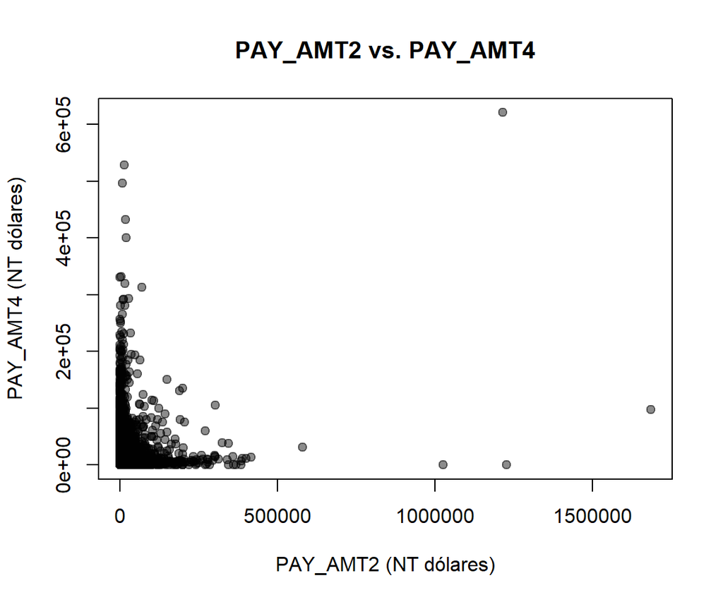

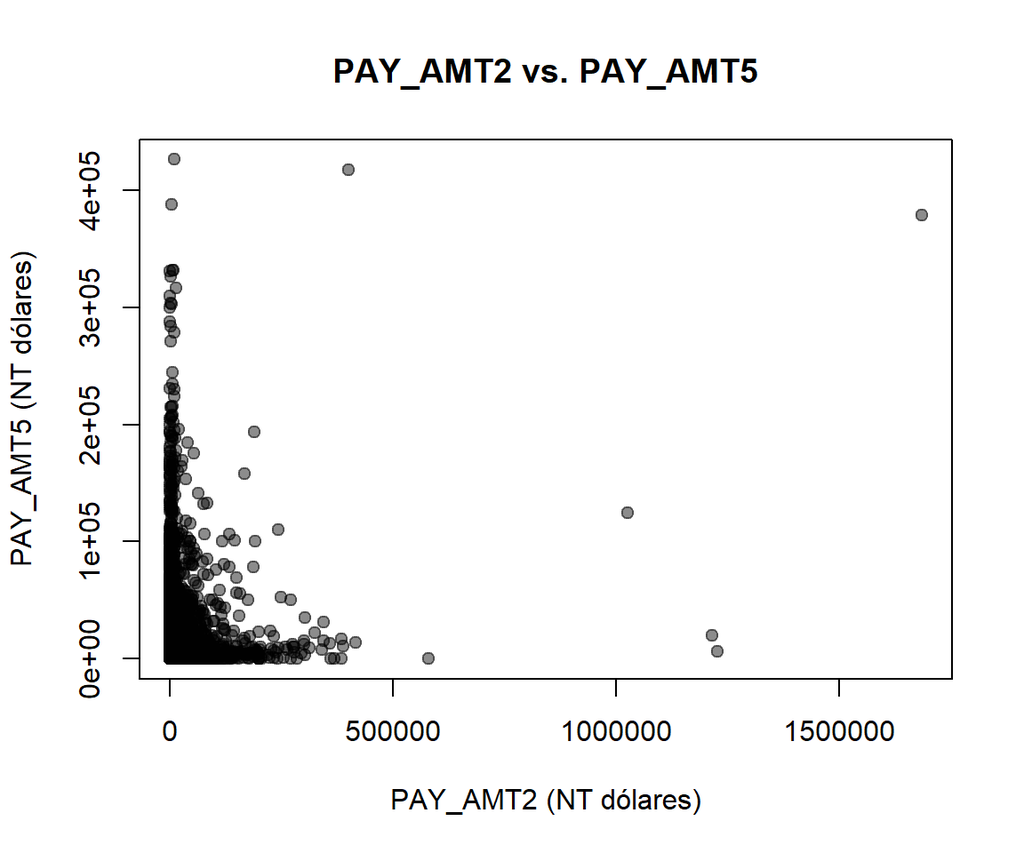

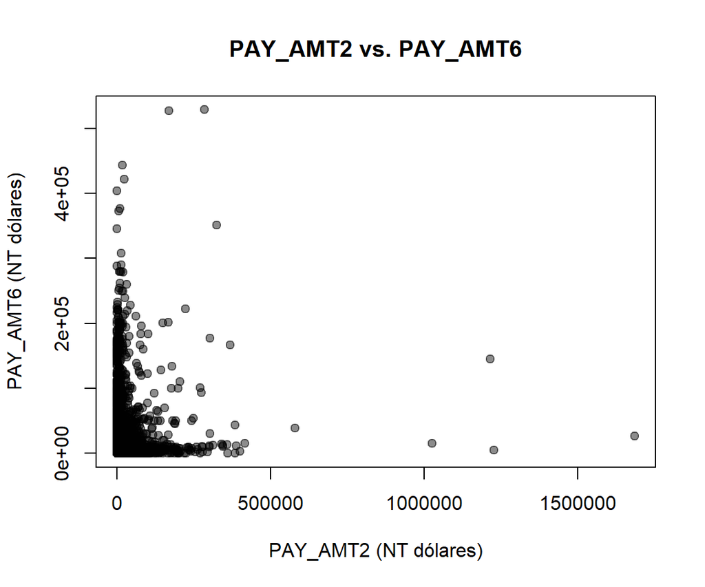

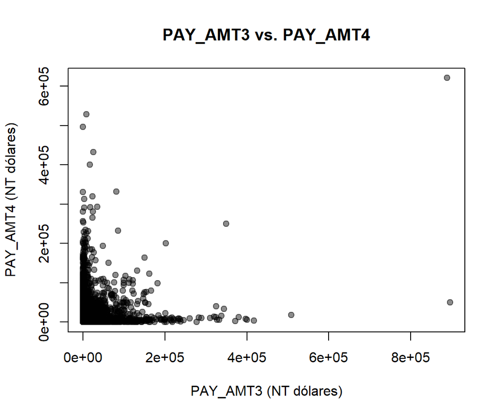

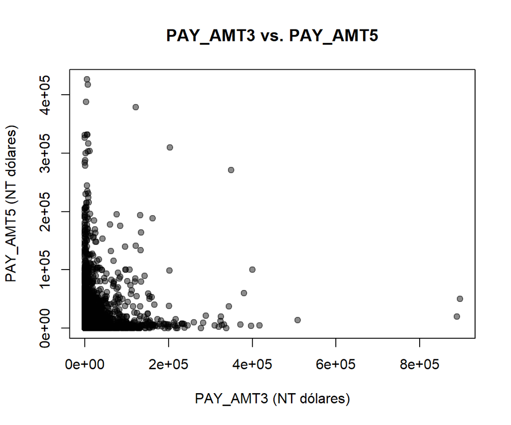

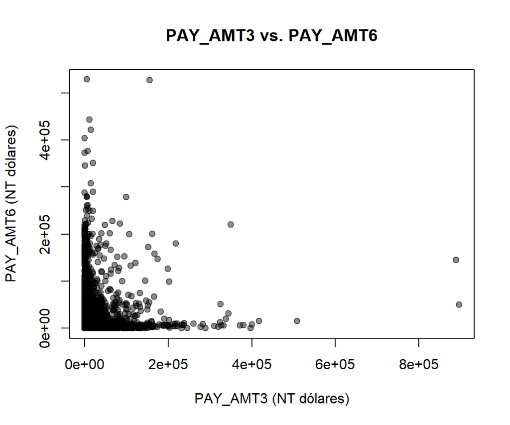

[3 more figures not shown]

**Interpretación:**

Este conjunto de gráficos representa la comparación entre los **montos de pago (`PAY_AMT`) de diferentes períodos**, permitiendo observar su comportamiento entre meses.

Los gráficos presentan una concentración considerable de observaciones en valores bajos y una menor cantidad de puntos en valores elevados.

Entre algunos períodos se observa una mayor concentración alrededor de una tendencia definida, mientras que en otras comparaciones existe una dispersión más amplia.

También se observan diferencias en la distribución de los pagos entre los distintos períodos, con algunos meses presentando una mayor presencia de valores elevados y otros concentrando sus observaciones cerca de cero.

En general, las comparaciones entre los diferentes `PAY_AMT` muestran que existe una **variabilidad considerable en los montos de pago entre períodos**, aunque se mantienen patrones similares de concentración en los valores bajos.